# 1_prepareForCytoscape

Ryan Rebernick

2/26/2021

# 1. Load packages

```r
library('plyr')
library('dplyr')
library('magrittr')
library('data.table')

#BiocManager::install("biomaRt")
library('biomaRt')
library('ggplot2')
library('scales')
```

# 2. Prepare Metabolite data

Input data was obtained through the following process: - Took list of metabolites shown to be changed following treatment with lactobacillus reuteri in SW480 and HCT cells - Converted the common names of these metabolites to HMDB files using the GUI version of metaboanalyst v5.0 (https://www.metaboanalyst.ca/faces/upload/ConvertView.xhtml). This was done via GUI because a fair number of the compounds were not directly identified and had to be selected from a list of suspected matches. - Once these HMDB ids were obtained, MetaBridge v1.2 (https://www.metabridge.org/) was used to get lists of genes associated with each compound - these were mapped using KEGG and MetaCyc. Both values were taken (see below)

The below code combines the kegg and metacyc hits for the HCT and SW cell lines, selecting for variables needed.

```r
#  Load metabridge data
kegg <- fread('~/Desktop/projects/reuterin/int/metabolites_SwHctSig_HMDB_metaboAnalyst_5.0_mapped_KEGG.tsv', data.table = F)
met <- fread('~/Desktop/projects/reuterin/int/metabolites_SwHctSig_HMDB_metaboAnalyst_5.0_mapped_MetaCyc.tsv', data.table = F)

# Prepare for merging
kegg$cg <- paste0(kegg$HMDB, '-', kegg$`Gene Name`)
met$cg <- paste0(met$HMDB, '-', met$`Gene Name`)

# Merge data frames
metabridge <- merge(kegg, met, by= 'cg')

# select values needed
metabridge$interaction <- 'mg'
metabridge %<>% dplyr::select(Compound.x, interaction, `Gene Name.y`, KEGG.x:`Enzyme Name`, Reaction:`MetaCyc Gene`, Ensembl)
colnames(metabridge) <- c('compound', 'interaction', 'gene', 'KEGG', 'HMDB', 'Enzyme', 'enzyme_name', 'rxn', 'rxn_name', 'metaCyc_gene', 'ensembl')

# shorten for export to cytoscape
export <- metabridge %>% dplyr::select(compound:gene) %>% unique()
```

# 3. Add Proteomics data

Cysteine proteomics data was done at the Univeristy of michigan to look at cysteines preferentially bound by reuterin. The lab recommended a cutoff of 2, but as this yielded only 3 compounds instead a value of >Mean + 3SD in any of the cr values. My understanding is the CR values are basically a ratio comparing reuterin and a random compound. The higher the ratio the more reuterin binds that cysteine site.

```r
# load and rename cols
prot <- fread('~/Desktop/projects/reuterin/data/UMichigan_Hannah_HCT_Cys_SLC-ABPP.txt', data.table = F)
colnames(prot)[28:32] <- c('cr5', 'cr25', 'cr50', 'cr100', 'gene-site')

# Correct excel's goofy date switches
prot$gene_symbol <- ifelse(prot$gene_symbol == '10-Sep', 'SEP10', prot$gene_symbol)
prot$gene_symbol <- ifelse(prot$gene_symbol == '9-Sep', 'SEPT9', prot$gene_symbol)

# Find values 3 SD above the mean of all CR values as cutoff
v <- mean(unlist(prot[,28:31])) + 3*(sd(unlist(prot[,28:31])))

# Filter for significant proteins
prot$cpmax <- apply(prot[, 28:31], 1, max)
prot %<>% dplyr::filter(cr5 > v | cr25 > v | cr50 > v | cr100 > v)

# Select cols of interest
prot %<>% dplyr::select(gene_symbol, cpmax)
colnames(prot) <- c('gene', 'cpmax')

# take only highest cp value for each gene
prot %<>%
    group_by(gene) %>%
    summarise(cpmax= max(cpmax))

# combine with metabolite data
export <- merge(export, prot, all.x = T, by = 'gene')

# Add boolean proteomiccs value
export$cpBoolean <- ifelse(is.na(export$cpmax), F, T)
```

# 4. Convert Human metabolite/cysteiene proteomics to mouse

RNA-seq was done in mouse, while the proteomics and metabolomics were done in human cell lines.

```r
require("biomaRt")

# access biomart
human = useMart("ensembl", dataset = "hsapiens_gene_ensembl")
mouse = useMart("ensembl", dataset = "mmusculus_gene_ensembl")

# convert human common -> human ensembl -> mouse mgi
genes = getLDS(attributes = c("hgnc_symbol"), filters = "hgnc_symbol", values = export$gene , mart = human, attributesL = c("ensembl_gene_id"), martL = human, uniqueRows=T)
colnames(genes) <- c('gene', 'ensembl')
genes2 = getLDS(attributes = c("ensembl_gene_id"), filters = "ensembl_gene_id", values = genes$ensembl , mart = human, attributesL = c("mgi_symbol"), martL = mouse, uniqueRows=T)
colnames(genes2) <- c('ensembl', 'mgi')

# choose single mgi id when returned 1+ for multiple human ensebml ids. Already optimally ordered for duplicate removal
t <- merge(genes, genes2, all.x = T, by = 'ensembl')
t <- t[!duplicated(t$gene),]

# merge new mouse gene names with pertinent metabolite/proteomics data and select cols
export <- merge(export, t, all.x = T, by='gene')
export %<>% dplyr::select(compound, interaction, mgi, cpmax, cpBoolean) %>% unique()
```

# 5. Add Gene Expression

Add in RNA-seq data and export file for use with cytoscape. This export contains all the nodes but ones following will subset based on interesting compounds.

```r
# load rna
rna <- fread('~/Desktop/projects/reuterin/data/ReutvsCtrl.txt')

# get DEGs and select needed cols
rna %<>% dplyr::filter(FDR < 0.05) %>%
  dplyr::select(genes, logFC)

# select cols
colnames(rna) <- c('mgi', 'logFC')

# merge data frames and order cols
export <- merge(export, rna, all.x = T, by= 'mgi')

# Add differentially expressed column
export$de <- 100
export$de <- ifelse(export$logFC > 0, 1, export$de)
export$de <- ifelse(export$logFC < 0, -1, export$de)
export$de <- ifelse(is.na(export$logFC), 0, export$de)

# select desired cols
export %<>% dplyr::select(compound, interaction, mgi, cpmax, cpBoolean, logFC, de)

# Add source target info
export$source <- T
export$target <- T

# save info keeping only unique nodes
write.table(export, '~/Desktop/projects/reuterin/int/metabolite-gene.txt', sep = '\t', quote = F, row.names = F)
```

# 6. Barplot of metabolite hits

Use this barplot to justify why the network was further narrowed down. Will show the number of DE genes as well as those with cysteine proteomics hits.

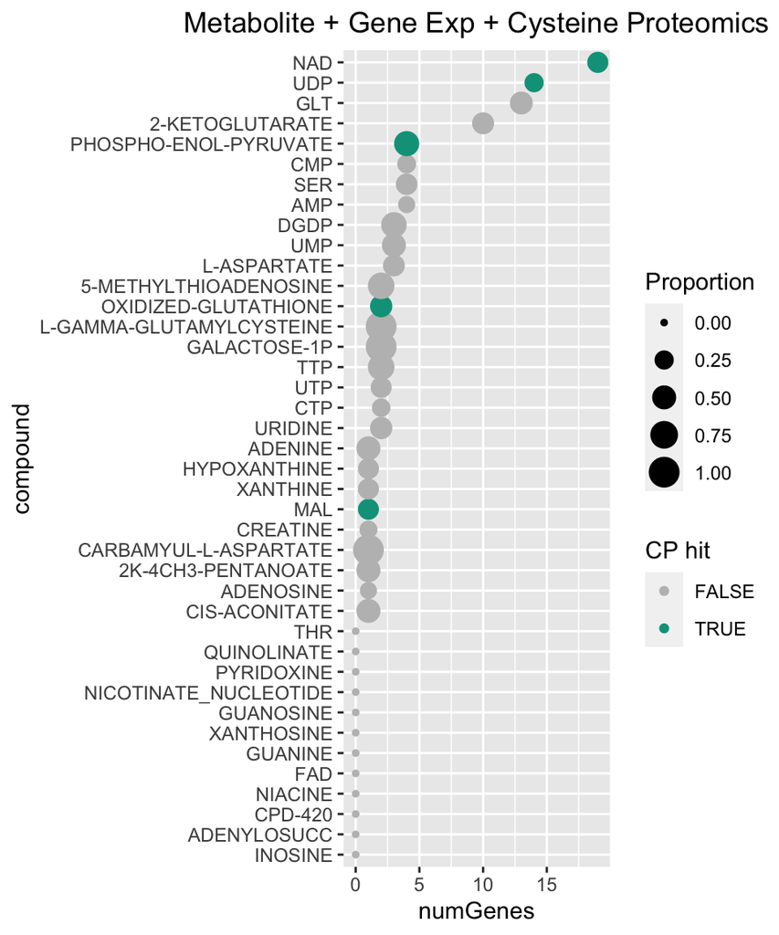

```r
# create seperate data frame
plot <- export

# determine whether this gene-compound interaction has a DE gene
plot$total <- ifelse(plot$de != 0, 1, 0)

# Prepare for plotting
plot <- plot %>%
  ##for each compound
  group_by(compound) %>%
  ## get number of total genes associated
  mutate(numGenes = sum(total)) %>%
  ##calculate the proportion of the total genes DE
  mutate(proportion = sum(total)/length(compound)) %>%
  ##create a T/F value if gene is a cysteine proteomics hit
  mutate(cp = sum(cpBoolean)>0) %>%
  ##select cols and get unique vals
  dplyr::select(compound, numGenes, proportion, cp) %>%
  unique() %>%
  # arrange by number of genes and make factor for plotting
  arrange(numGenes) %>%
  mutate(compound = factor(compound, levels = .$compound))

# Plot dotplot
ggplot(plot, aes(numGenes, compound)) +
  geom_point(aes(size=proportion, col=cp)) +
  scale_color_manual(values=c("grey", "#00A08A")) +
  ggtitle("Metabolite + Gene Exp + Cysteine Proteomics") +
  theme(plot.title = element_text(hjust = 0.5)) +
  labs(size="Proportion", colour= "CP hit")
```

# 7. Subset cytoscape export for only top hits Choosing those with top # DE genes or any with a cysteine proteomics hit

```r
# keep the top x compounds and those with cystine proteomics hits
plot %<>% arrange(-numGenes)
## pull compund names
keep <- c(as.character(plot$compound[1:4]), as.character(plot[plot$cp >0,]$compound))
## get compounds of interest and select only the genes that have proteomics hit or are DE
export.sub <- export %>%
  dplyr::filter(compound %in% keep) %>%
  dplyr::filter(de != 0 | cpBoolean ==T)

# save info keeping only unique nodes
write.table(export.sub, '~/Desktop/projects/reuterin/int/metabolite-gene_subset.txt', sep = '\t', quote = F, row.names = F)
```